# Update on drugs prescribed in phenomenal recovery cohort

Lucie Bourguignon

2023-05-31

## Background

We discussed last week that I should start working on the drugs prescribed to the patients wxhibiting a phenomenal recovery. As a start, we decided to focus on:

- statins
- drugs with negative effects reported in our drug review: morphine, ethanol, caffeine, pregabalin
- methylprednisolone (MP) (more specifically, was the first dose given within in the first 4h following SCI?)
- drugs that the patients with phenomenal recovery have in common

## Statins

We don’t have any statins prescribed in the Sygen data as they only entered the market in the 90’s. Statins are part of our drugs of interest for the drug review as they were prescribed in the SCIRehab dataset.

## Drugs with negative effects (drug review)

### Caffeine

No patient with caffeine prescription.

### Ethanol

One patient with ethanol prescribed in the Sygen, but not a severe injury (so also not a phenomenal recovery).

### Pregabalin

Similar situation as for the statins: none prescribed in the Sygen data.

## Methylprednisolone

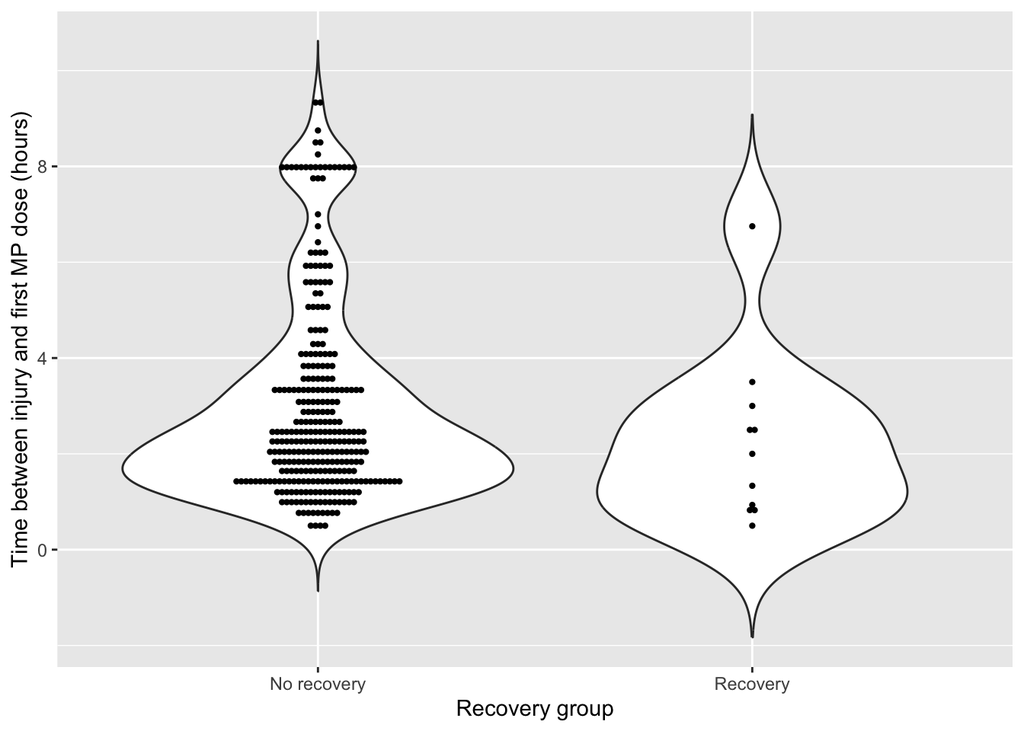

This plot shows the time at which the first dose of MP was received after injury, separately for the groups with no phenomenal recovery (left) and phenomenal recovery (right).

```r
time_MP_no_recovery <- df_window.1.4 %>% filter(rec_AIS_motor_imp == 'No recovery') %>% select(I_MPM)
time_MP_recovery <- df_window.1.4 %>% filter(rec_AIS_motor_imp == 'Recovery') %>% select(I_MPM)
ks.test(as.vector(time_MP_no_recovery)$I_MPM, as.vector(time_MP_recovery)$I_MPM)
```

```
##
##  Exact two-sample Kolmogorov-Smirnov test
##
## data:  as.vector(time_MP_no_recovery)$I_MPM and as.vector(time_MP_recovery)$I_MPM
## D = 0.30753, p-value = 0.1956
## alternative hypothesis: two-sided
```

There is no statistical difference in the distribution of time when MP was first received when comparing the recovery vs non-recovery groups.

## Common drugs within the recovery group

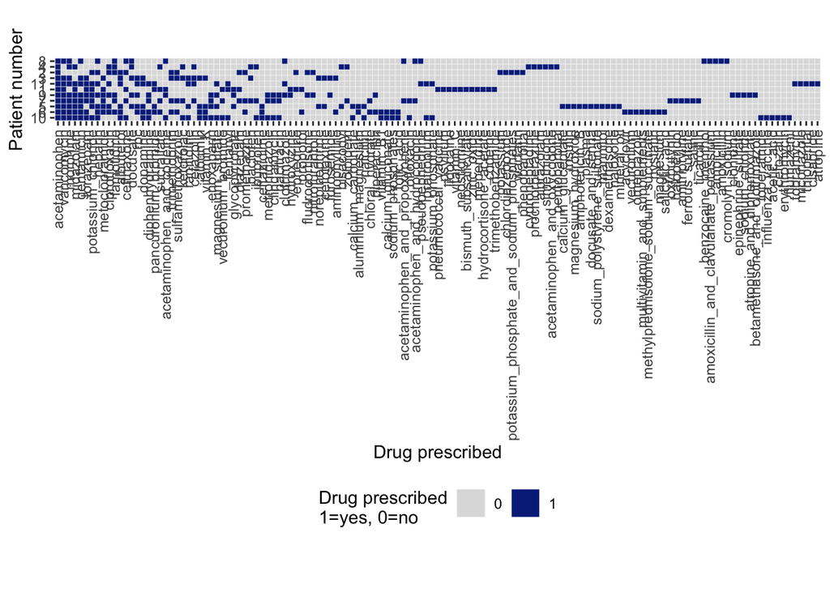

This plot shows all the drugs that were prescribed to at least 1 of the 11 patients with a phenomenal recovery **in the first year after injury**. Y-axis is ordered from patient with the most unique drugs prescribed at the bottom to least unique drugs prescribed at the top. X-axis is ordered from highest prevalence to lowest prevalence in the 11 phenomenal recovery, from left to right

Looking more closely at the drugs that were prescribed in the majority of the patients (>5), **in the first year after injury** (left) or the same drugs **in the first 30 days after injury** (right)

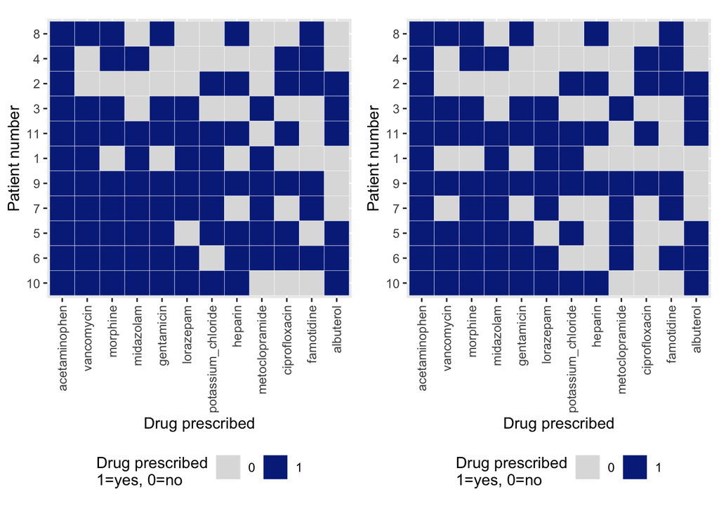

### Comparison with the cohort with severe SCI but no phenomenal recovery

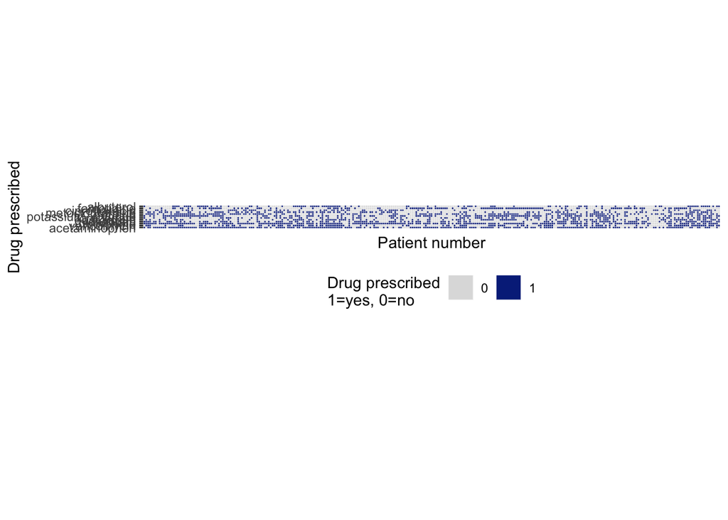

However, since the number of patients is a lot bigger in the cohort, the plot is not very informative.

Instead, we can display this information in a graph.

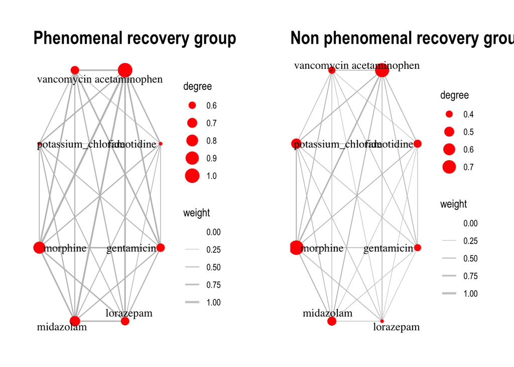

Here the size of the nodes represents the proportion of patients in the respective cohorts that received a certain drug. The width of the edges represents the proportion of patients that received the 2 linked drugs. Here we are considering drugs given in the first 30 days after injury.

The corresponding numbers are:

```
## # A tibble: 12 × 3
##    drug               number proportion
##    <fct>               <dbl>      <dbl>
##  1 acetaminophen          11      1
##  2 albuterol               6      0.545
##  3 ciprofloxacin           4      0.364
##  4 famotidine              6      0.545
##  5 gentamicin              7      0.636
##  6 heparin                 5      0.455
##  7 lorazepam               7      0.636
##  8 metoclopramide          5      0.455
##  9 midazolam               8      0.727
## 10 morphine                9      0.818
## 11 potassium_chloride      6      0.545
## 12 vancomycin              7      0.636
```

```
## # A tibble: 12 × 3
##    drug               number proportion
##    <fct>               <dbl>      <dbl>
##  1 acetaminophen         223      0.741
##  2 albuterol              95      0.316
##  3 ciprofloxacin          84      0.279
##  4 famotidine            129      0.429
##  5 gentamicin            121      0.402
##  6 heparin               158      0.525
##  7 lorazepam             108      0.359
##  8 metoclopramide        113      0.375
##  9 midazolam             139      0.462
## 10 morphine              233      0.774
## 11 potassium_chloride    156      0.518
## 12 vancomycin            122      0.405
```